```
Current Working directory  C:\Users\User\Google Drive\FUBerlin\Masterarbeit\Analysis\Finding_K
```

# 1 Analyzing Amasino's (Dianna's) data

## 1.1 Data prep

### 1.1.1 Import

```
   ID  aSS  aLL  tSS  tLL  choseLL        rt  choseLeft  condition
0   1  4.0   10    0  365      1.0  4.804574          0          2
1   1  3.0   10    0  365      1.0  1.341040          0          2
2   1  7.5   10    0   30      1.0  1.831145          1          2
3   1  3.5   10    0    7      1.0  1.576825          1          2
4   1  7.0   10    0   15      1.0  1.698946          1          2
5   1  0.5   10    0  180      1.0  1.861560          1          2
6   1  7.0   10    0    1      1.0  2.772035          0          2
7   1  9.0   10    0  365      0.0  2.590511          0          2
8   1  1.0   10    0   15      1.0  2.705389          1          2
9   1  3.0   10    0   15      1.0  2.111287          0          2
```

### 1.1.2 Adding variables (choseSS and reward for each trial)

## 1.2 Defining k

```
k =
```

$\displaystyle \frac{\frac{aLL}{aSS} - 1}{tLL}$

k is an individual parameter for the strength of the delay discount. The higher k, the higher the incentive for aSS. Every question has a certain k, assuming that the subjective value of aSS is is equal to aLL

```
   ID  aSS  aLL  tSS  tLL  choseLL        rt  choseLeft  condition  choseSS  \
0   1  4.0   10    0  365      1.0  4.804574          0          2      0.0
1   1  3.0   10    0  365      1.0  1.341040          0          2      0.0
2   1  7.5   10    0   30      1.0  1.831145          1          2      0.0
3   1  3.5   10    0    7      1.0  1.576825          1          2      0.0
4   1  7.0   10    0   15      1.0  1.698946          1          2      0.0

   reward  aSS_aLL_ratio  aLL_tLL_ratio         k
0    10.0           0.40       0.027397  0.004110
1    10.0           0.30       0.027397  0.006393
2    10.0           0.75       0.333333  0.011111
3    10.0           0.35       1.428571  0.265306
4    10.0           0.70       0.666667  0.028571
```

Since, aSS < aLL, we want to know at which discount parameters k aSS is never preferred over aLL

```
      aSS  aLL  aSS_aLL_ratio  tLL          k  N_choseSS    N   choseSS
0     0.5   10           0.05    1  19.000000        0.0  117  0.000000
1     0.5   10           0.05    7   2.714286        2.0  115  0.017391
2     0.5   10           0.05   15   1.266667        1.0  116  0.008621
3     0.5   10           0.05   30   0.633333        4.0  113  0.035398
4     0.5   10           0.05   90   0.211111       11.0  116  0.094828
..    ...  ...            ...  ...        ...        ...  ...       ...
136   9.5   10           0.95   30   0.001754       75.0  116  0.646552
137   9.5   10           0.95   90   0.000585       85.0  114  0.745614
138   9.5   10           0.95  180   0.000292       98.0  114  0.859649
139   9.5   10           0.95  365   0.000144      100.0  115  0.869565
140  10.0   10           1.00    1   0.000000      100.0  113  0.884956

[141 rows x 8 columns]
```

## 1.3 k relates do decision difficulty

Check if k and P(chose SS) can be modeled

```
Length: 141
k Min: 0.0     k Max: 19.0
```

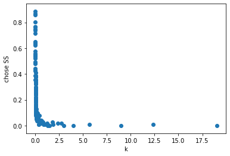

Find the k's where the decision is difficult

```
Number of datapoints: 109
k Min: 0.0     k Max: 0.4111111111111112
```

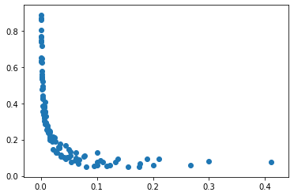

## 2 WebET conditions (my study)

### 2.1 What k-range to choose?

$\displaystyle \frac{\frac{aLL}{aSS} - 1}{tLL}$

**k Min**

k is small if one of the two conditions are met:

- aSS is large
- tLL is large

Question 1: With the minimum difference between aSS and aLL (largest aSS), how small should the delay be at minimum for a difficult decision?

**k Max**

k is large if one of the two conditions are met:

- aSS is small
- tLL is small

```
Amasino Conditions:
k Min: 0.0     k Max: 0.4111111111111112

                       Description  aSS  aLL  Delay         k
3             Large aSS, max delay  4.5  5.0    365  0.000304
2             Small aSS, max delay  1.0  5.0    365  0.010959
5    Large aSS, min required delay  4.5  5.0      7  0.015873
4    Small aSS, max allowed  delay  1.0  5.0    180  0.022222
1   Large aSS/aLL-ratio, min delay  4.5  5.0      1  0.111111
0  Large aSS/aLL-ratio, min  delay  1.0  1.5      1  0.500000
```

### 2.2 Generate Conditions

[output not shown]

# 3 Compare Trial Characteristics

## 3.1 k-parameter (aLL/aSS - 1) / tLL)

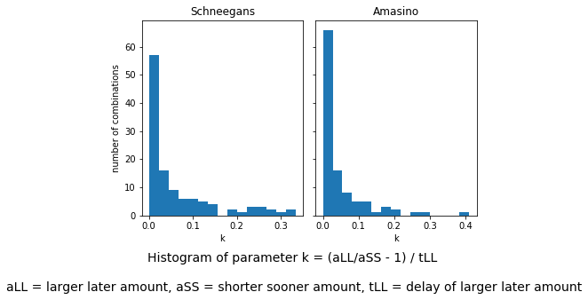

## 3.2 Delays (tLL)

### 3.2.1 Frequency of shorter-sooner-options (i.e. number of conditions)

My task has a few more trials (in relative numbers) with 7 days. Apart from that, the distributions are similar.

```
   tLL  freq_schneegans  freq_amasino  rel_schneegans  rel_amasino
0    1                6             4        0.051282     0.044944
1    7               18            10        0.153846     0.112360
2   15               21            16        0.179487     0.179775
3   30               24            19        0.205128     0.213483
4   90               24            20        0.205128     0.224719
5  180               24            20        0.205128     0.224719
```

[figure not shown]

### 3.2.2 Shorter-sooner-amount distribution for each delay option

```
[ 30  90 180  15   7   1]
```

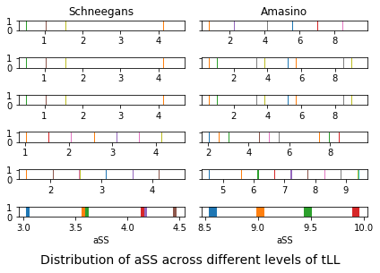

### 3.2.3 Shorter-sooner-amount vs. k for each delay option

Amasino has a wider range of rewards, thats why there is a smoother k-function. Within a delay of 30-180 days, we allow Amasino to have a smaller amounts (< 2.5), which increases k. That's because my aSS/aLLL ratio is naturally limited to 0.50 vs. 5 (Amasino has 0.50 vs. 10).

```
From top to bottom:[ 30  90 180  15   7   1]
```

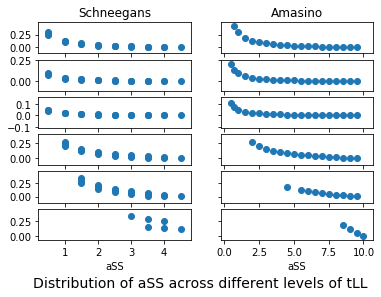

```
From top to bottom:[ 30  90 180  15   7   1]
```

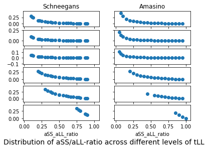

## 3.3 Smaller sooner amounts (aSS)

At both studies, all kinds of smaller-sooner-amounts are present in a fair number, expect 5.5 for Amasino.

### 3.3.1 Frequency of conditions

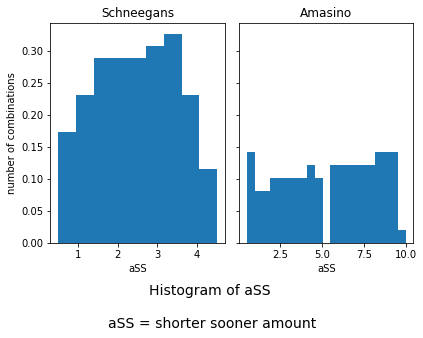

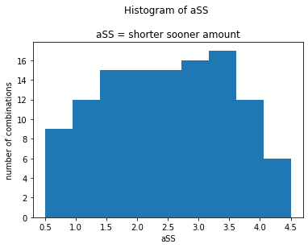

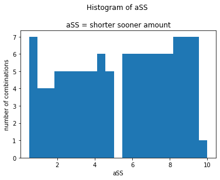

### 3.3.2 k-values

Similar distribution between the studies. larger varying k for smaller shorter-sooner-amounts (aSS).

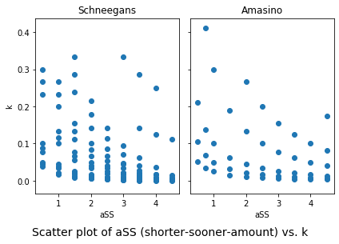

## 3.4 Larger-later-reward-delay-ratio (aLL/tLL)

The ratio between the larger-later-amount (aLL) and its delay (tLL) is similar distributed between the studies. There are more combinations for small ratios (long delays, e.g. 30, 90, 180) and a few large ratios (1 day delay).

[figure not shown]

## 3.5 Reward-ratio (aSS/aLL)

The ratio between the rewards is similar between the two studies

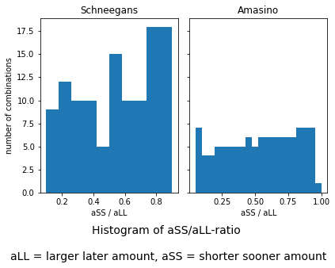